# A Solution to the Price Puzzle on US Data

Authors

Florian Jacquetin

Loman Sezestre

Published

December 30, 2025

This project aims at studying the price puzzle, a macroeconomic paradox observed by Sims (1980), when an increase of interest rate is sometimes followed by an increase of inflation in macroeconometric models.

It is designed as follows :

1. Data
2. Price Puzzle in the NK framework
3. Price Puzzle in US data
4. Solving the Price Puzzle: pre-Volcker regime
5. Extensions to post-Volcker regimes

# 1 Data

```r
packages <- c(
  "tidyverse",
  "lubridate",
  "zoo",
  "fredr",
  "openxlsx",
  "mFilter",
  "R.matlab",
  "strucchange",
  "vars"
)

to_install <- packages[!packages %in% installed.packages()[, "Package"]]
if(length(to_install) > 0) install.packages(to_install)

for(p in packages) library(p, character.only = TRUE)

source("utils.R")
```

Output gap (https://www.cbo.gov/data/budget-economic-data)

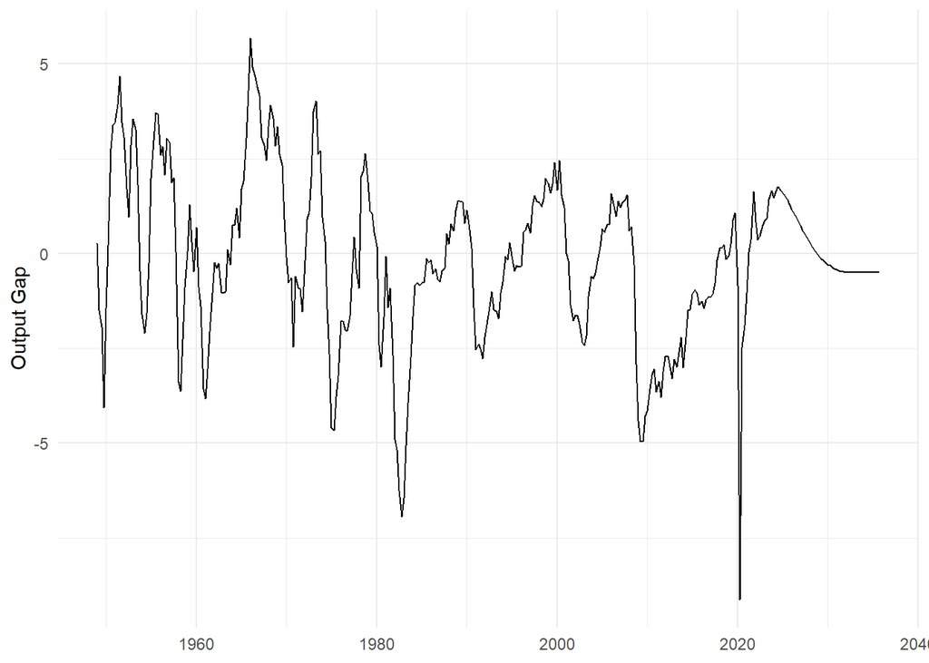

GDP Deflator and Inflation (FREDR)

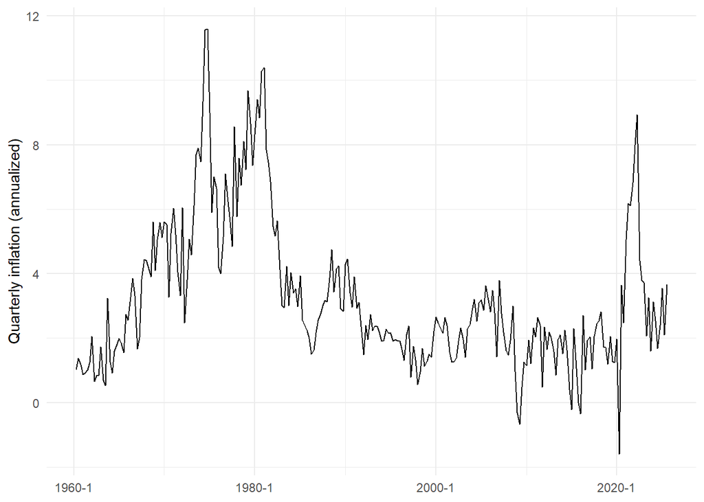

```r
fredr::fredr_set_key("2081d90b146ea654a4866e909178bfaf")

gdpdef <- fredr::fredr(
  series_id = "GDPDEF",
  observation_start = as.Date("1960-01-01")
) %>%
  transmute(
    date = as.yearqtr(date),
    p_gdp = log(value)
  ) %>%
  arrange(date)

pi_gdp <- gdpdef %>%
  mutate(
    pi = 400 * (p_gdp - lag(p_gdp))    # inflation trimestrielle annualisée
  ) %>%
  drop_na() %>%
  dplyr::select(date, pi)

ggplot(pi_gdp, aes(date, pi)) +
  geom_line() +
  theme_minimal() +
  labs(x = NULL, y = "Quarterly inflation (annualized)")
```

```r
ggsave("sorties/inflation.png", width = 7, height = 4, dpi = 300)
```

Federal Funds Rate (FREDR)

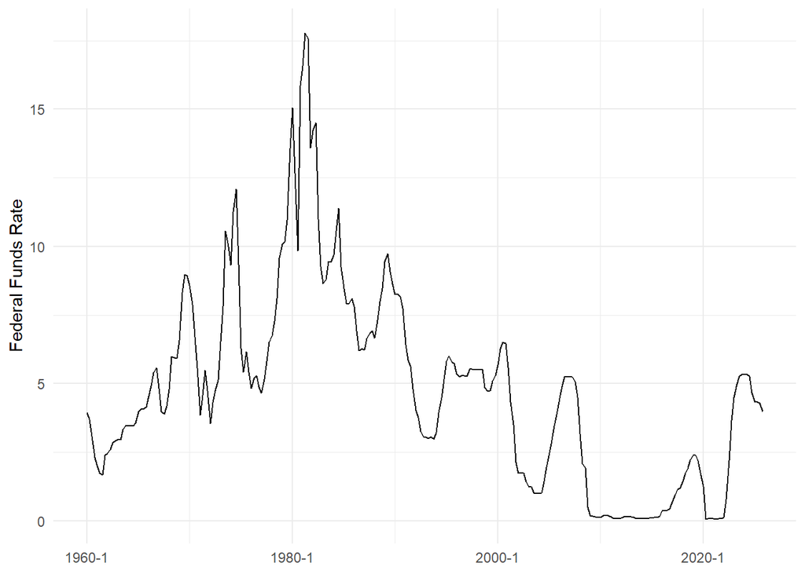

```r
ffr_m <- fredr::fredr(
  series_id = "FEDFUNDS",
  observation_start = as.Date("1960-01-01")
) %>%
  transmute(
    date_m = as.yearmon(date),
    ffr = value
  )

ffr_q <- ffr_m %>%
  mutate(
    date = as.yearqtr(date_m)
  ) %>%
  group_by(date) %>%
  summarise(
    ffr = mean(ffr, na.rm = TRUE)
  ) %>%
  ungroup() %>%
  arrange(date)
# %>%
# filter(date <= "2006 Q4")

ggplot(ffr_q, aes(date, ffr)) +
  geom_line() +
  theme_minimal() +
  labs(x = NULL, y = "Federal Funds Rate")
```

```r
ggsave("sorties/ffr.png", width = 7, height = 4, dpi = 300)
```

Inflation Forecast (Greenbook)

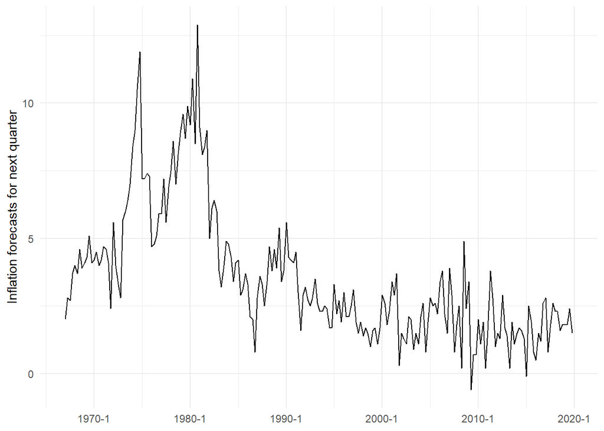

```r
df <- read.xlsx("data/gPGDP_1967_1984.xlsx")
df2 <- read.xlsx("data/gPGDP_1985_Last.xlsx")

df_long <- df %>%
  mutate(Date = as.character(Date)) %>%
  separate(
    Date,
    into = c("year", "qtr"),
    sep = "\\.",
    convert = TRUE
  ) %>%
  pivot_longer(
    cols = starts_with("gPGDP_"),
    names_to = "vintage",
    values_to = "forecast"
  ) %>%
  mutate(
    vintage_date = ymd(substr(vintage, 7, 14)),
    quarter_start = make_date(year, (qtr - 1) * 3 + 1, 1),
    target_quarter_start = quarter_start %m+% months(3)
  ) %>%
  filter(!is.na(forecast))

selected_forecasts <- df_long %>%
  mutate(
    is_before = vintage_date < target_quarter_start,
    distance_days = abs(as.numeric(vintage_date - target_quarter_start))
  ) %>%
  group_by(year, qtr) %>%
  arrange(
    desc(is_before),
    distance_days
  ) %>%
  slice(1) %>%
  ungroup()

result <- selected_forecasts %>%
  transmute(
    quarter = paste0(year, "Q", qtr),
    target_quarter = paste0(
      year(target_quarter_start),
      "Q",
      lubridate::quarter(target_quarter_start)
    ),
    forecast_next_q = forecast,
    vintage_date
  ) %>%
  slice(-c(1:4)) %>%
  slice(-((n() - 3):n()))

df2_long <- df2 %>%
  mutate(Date = as.character(Date)) %>%
  separate(
    Date,
    into = c("year", "qtr"),
    sep = "\\.",
    convert = TRUE
  ) %>%
  pivot_longer(
    cols = starts_with("gPGDP_"),
    names_to = "vintage",
    values_to = "forecast"
  ) %>%
  mutate(
    vintage_date = ymd(substr(vintage, 7, 14)),
    quarter_start = make_date(year, (qtr - 1) * 3 + 1, 1),
    target_quarter_start = quarter_start %m+% months(3)
  ) %>%
  filter(!is.na(forecast))

selected_forecasts2 <- df2_long %>%
  mutate(
    is_before = vintage_date < target_quarter_start,
    distance_days = abs(as.numeric(vintage_date - target_quarter_start))
  ) %>%
  group_by(year, qtr) %>%
  arrange(
    desc(is_before),
    distance_days
  ) %>%
  slice(1) %>%
  ungroup()

result2 <- selected_forecasts2 %>%
  transmute(
    quarter = paste0(year, "Q", qtr),
    target_quarter = paste0(
      year(target_quarter_start),
      "Q",
      lubridate::quarter(target_quarter_start)
    ),
    forecast_next_q = forecast,
    vintage_date
  ) %>%
  slice(-c(1:4)) %>%
  slice(-((n() - 7):n()))

greenbook <- rbind(result,result2) %>%
  mutate(date = as.yearqtr(quarter)) %>%
  dplyr::select(date,forecast_next_q)

ggplot(greenbook, aes(date, forecast_next_q)) +
  geom_line() +
  theme_minimal() +
  labs(x = NULL, y = "Inflation forecasts for next quarter")
```

```r
ggsave("sorties/inflation_forecast.png", width = 7, height = 4, dpi = 300)
```

We start with a model with 3 variables.

```r
df_us <- ogap %>%
  inner_join(pi_gdp, by = "date") %>%
  inner_join(ffr_q,  by = "date") %>%
  arrange(date)


print(head(df_us, 10))
```

```
      date      y_gap        pi      ffr
1  1960 Q2 -0.8836612 1.0098727 3.696667
2  1960 Q3 -1.3881528 1.3683171 2.936667
3  1960 Q4 -3.5783399 1.1838135 2.296667
4  1961 Q1 -3.8258301 0.8727463 2.003333
5  1961 Q2 -3.0387802 0.9220135 1.733333
6  1961 Q3 -2.0514700 1.0219730 1.683333
7  1961 Q4 -1.0342937 1.2483689 2.400000
8  1962 Q1 -0.2418696 2.0551249 2.456667
9  1962 Q2 -0.3813454 0.6574374 2.606667
10 1962 Q3 -0.2496653 0.8328867 2.846667
```

We run a Chow test to find the best break point, following Paul Volcker’s appointment at the Fed.

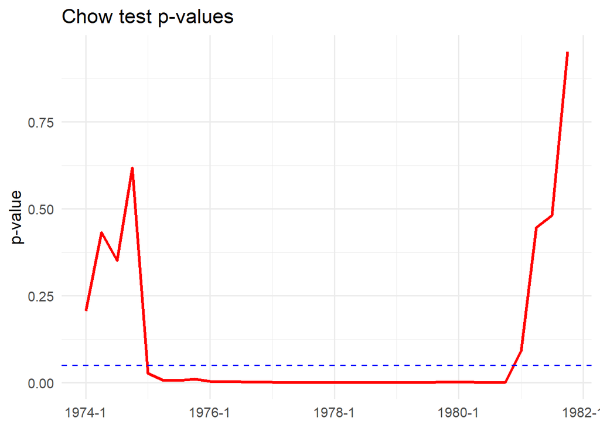

```r
df <- df_us %>%
  filter(date <= as.yearqtr("2008 Q4")) %>%
  dplyr::select(-date)

lags <- VARselect(df)$selection["SC(n)"]
var_fit <- VAR(df, p = lags, type = "const")
ffr_eq <- var_fit$varresult$ffr

df_model <- ffr_eq$model

y <- df_model[[1]]
X <- model.matrix(ffr_eq)

dates_est <- (df_us %>% filter(date <= as.yearqtr("2008 Q4"))) %>%
  pull(date)

dates_est <- dates_est[(lags + 1):length(dates_est)]

dates_est_chr <- as.character(dates_est)

quarters <- seq(as.yearqtr("1974 Q1"), as.yearqtr("1981 Q4"), by = 0.25)

p_values <- numeric(length(quarters))

for (i in seq_along(quarters)) {

  bp <- which(dates_est == quarters[i])

  if (length(bp) == 1 && bp > 1 && bp < length(y)) {
    chow <- sctest(y ~ X - 1, type = "Chow", point = bp)
    p_values[i] <- chow$p.value
  } else {
    p_values[i] <- NA
  }
}

p_df <- data.frame(
  Quarter = quarters,
  P_value = p_values
)


ggplot(p_df, aes(x = Quarter, y = P_value)) +
  geom_line(color = "red", linewidth = 1.2) +
  geom_hline(yintercept = 0.05, linetype = "dashed", color = "blue") +
  theme_minimal(base_size = 14) +
  labs(
    title = "Chow test p-values",
    x = NULL,
    y = "p-value"
  )
```

```r
ggsave("sorties/chow1.png", width = 7, height = 4, dpi = 300)
```

We run another Chow test to find a break point during the 2008 crisis.

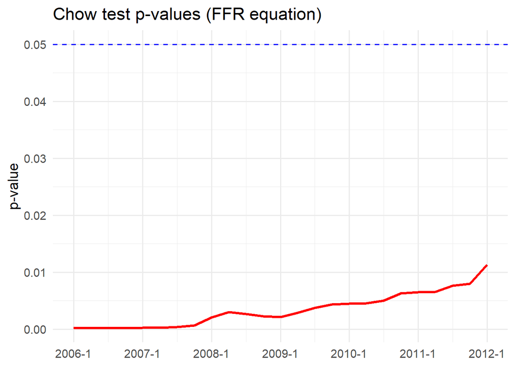

```r
df_us_sub <- df_us %>%
  filter(date >= as.yearqtr("1979 Q4"))

df <- df_us_sub %>%
  dplyr::select(-date)

select_order <- VARselect(df)
lags <- select_order$selection["SC(n)"]
var_fit <- VAR(df, p = lags, type = "const")

ffr_eq <- var_fit$varresult$ffr

df_model <- ffr_eq$model
y <- df_model[[1]]
X <- model.matrix(ffr_eq)

dates_full <- df_us_sub$date
dates_est <- dates_full[(lags + 1):length(dates_full)]

quarters <- seq(as.yearqtr("2006 Q1"), as.yearqtr("2012 Q1"), by = 0.25)

p_values <- numeric(length(quarters))

for (i in seq_along(quarters)) {

  bp <- which(dates_est == quarters[i])

  if (length(bp) == 1 && bp > 1 && bp < length(y)) {
    chow <- sctest(y ~ X - 1, type = "Chow", point = bp)
    p_values[i] <- chow$p.value
  } else {
    p_values[i] <- NA
  }
}

p_df <- data.frame(
  Quarter = quarters,
  P_value = p_values
)

ggplot(p_df, aes(x = Quarter, y = P_value)) +
  geom_line(color = "red", linewidth = 1.2) +
  geom_hline(yintercept = 0.05, linetype = "dashed", color = "blue") +
  theme_minimal(base_size = 14) +
  labs(
    title = "Chow test p-values (FFR equation)",
    x = NULL,
    y = "p-value"
  )
```

```r
ggsave("sorties/chow2.png", width = 7, height = 4, dpi = 300)
```

# 2 Price Puzzle in the NK framework

Here we simulate IRFs from a theoretical NK model.

Let’s observe the IRFs.

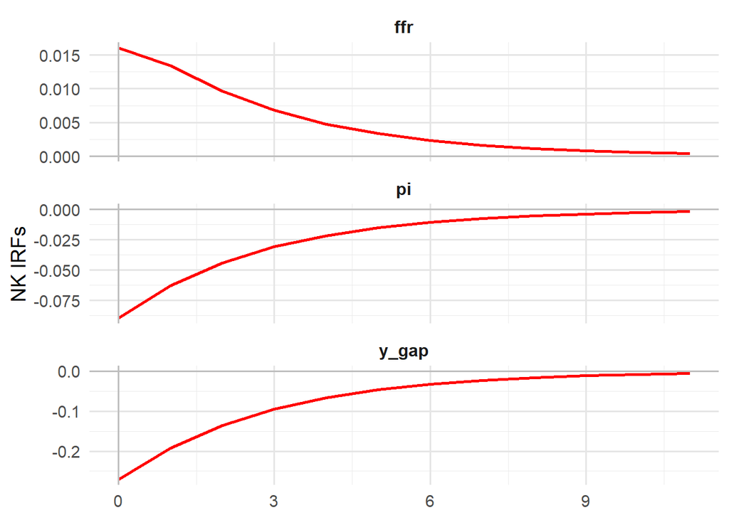

```r
mat_data <- R.matlab::readMat("nk_model/Output/nk_model_results.mat")
oo_matrix <- mat_data$oo.
irfs_list <- oo_matrix[[20]]

x_eb <- as.numeric(irfs_list[[7]])
pi_eb <- as.numeric(irfs_list[[8]])
int_eb <- as.numeric(irfs_list[[9]])

nk_df <- data.frame(
  horizon = 0:(length(x_eb)-1),
  y_gap = x_eb,
  pi = pi_eb,
  ffr = int_eb,
  check.names = FALSE
) %>%
  pivot_longer(cols = -horizon, names_to = "variable", values_to = "irf")

ggplot(nk_df, aes(x = horizon, y = irf)) +
  theme_minimal(base_size = 14) +
  geom_line(size = 1, color = "red") +
  facet_wrap(~variable, nrow = 3, scales = "free_y") +
  labs(title = NULL,
       x = NULL,
       y = "NK IRFs") +
  geom_hline(yintercept = 0, color = "grey", linetype = "solid") +
  geom_vline(xintercept = 0, color = "grey", linetype = "solid") +
scale_x_continuous(breaks = seq(0, 12, by = 3)) +
  theme(
    legend.position = "none",
    strip.text = element_text(face = "bold", size = 12),
    panel.grid.major = element_line(color = "gray90")
  )
```

```r
ggsave("sorties/nk.png", width = 4, height = 8, dpi = 300)
```

Based on this NK model, we simulate artificial but economically realistic macroeconomic time series and then estimate a VAR on these simulated data.

```r
#matlab_exec <- "C:/Program Files/MATLAB/R2024b/bin/matlab.exe"

#system(sprintf('"%s" -batch "dynare artificial_data.mod noclearall"',matlab_exec))

sim_data <- R.matlab::readMat("artificial_data/Output/artificial_data_results.mat")

oo_matrix <- sim_data$oo.

mat <- oo_matrix[,,1][[3]]

x_sim  <- mat[1, ]
pi_sim <- mat[2, ]
int_sim <- mat[3, ]

pi_star <- 2
i_star  <- 3

df_sim <- tibble(
  y_gap = as.numeric(x_sim),
  pi    = as.numeric(pi_sim) + pi_star,
  ffr   = as.numeric(int_sim) + i_star
)

lag_selection <- VARselect(df_sim, lag.max = 6)
p_sim <- lag_selection$selection["SC(n)"]
print(lag_selection)
```

```
$selection
AIC(n)  HQ(n)  SC(n) FPE(n)
     3      1      1      3

$criteria
                   1             2             3             4             5
AIC(n) -1.131065e+01 -1.131490e+01 -1.131567e+01 -1.125888e+01 -1.120331e+01
HQ(n)  -1.122880e+01 -1.117166e+01 -1.111105e+01 -1.099286e+01 -1.087591e+01
SC(n)  -1.110851e+01 -1.096116e+01 -1.081034e+01 -1.060194e+01 -1.039477e+01
FPE(n)  1.224211e-05  1.219108e-05  1.218384e-05  1.290011e-05  1.364439e-05
                   6
AIC(n) -1.119010e+01
HQ(n)  -1.080131e+01
SC(n)  -1.022995e+01
FPE(n)  1.383640e-05
```

```r
cat("Lag optimal (SC):", p_sim, "\n")
```

```
Lag optimal (SC): 1
```

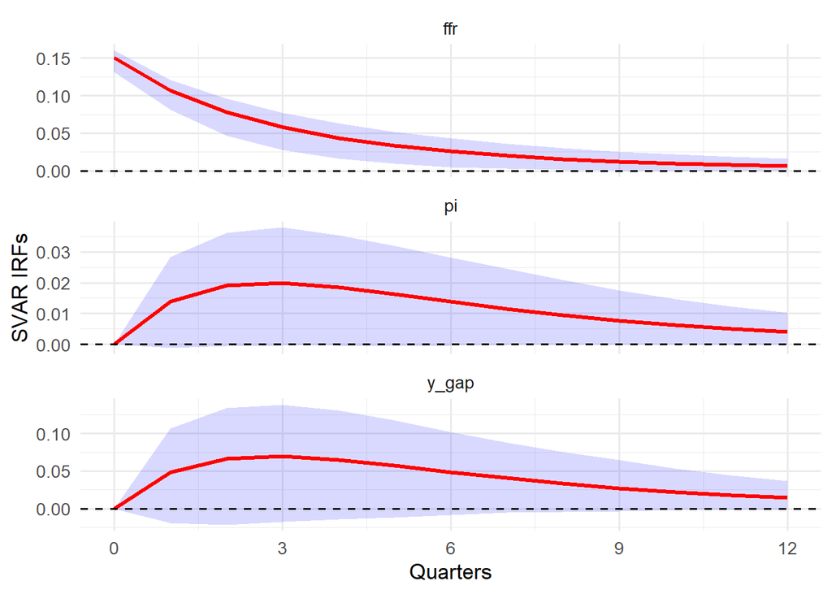

```r
var_sim <- VAR(df_sim, p = 1, type = "const")

irf_sim <- irf(
  var_sim,
  impulse = "ffr",
  response = c("y_gap", "pi", "ffr"),
  n.ahead = 12,
  boot = TRUE,
  runs = 500,
  ortho = TRUE
)


df_irf_sim <- irf_to_df(irf_sim, impulse_name = "ffr")

ggplot(df_irf_sim, aes(x = horizon, y = irf)) +
  geom_ribbon(aes(ymin = lower, ymax = upper), fill = "blue", alpha = 0.15) +
  geom_line(size = 1.2, color = "red") +
  geom_hline(yintercept = 0, linetype = "dashed") +
scale_x_continuous(breaks = seq(0, 12, by = 3)) +
  facet_wrap(~ variable,nrow=3, scales = "free_y") +
  labs(
    title = NULL,
    x = "Quarters",
    y = "SVAR IRFs"
  ) +
  theme_minimal(base_size = 13)
```

```r
ggsave("sorties/artificial_price_puzzle.png",
       width = 4, height = 8, dpi = 300)
```

# 3 Price Puzzle on US data

We construct a SVAR model based on real US data [og(t) pi(t) ffr(t)]

```r
# echo: false
Y_pre_ts  <- df_us %>%
  filter(date <= as.yearqtr("1979 Q3")) %>%
  df_to_ts()

Y_post_ts <- df_us %>%
  filter(date >= as.yearqtr("1979 Q4"),
         date <= as.yearqtr("2006 Q4")) %>%
  df_to_ts()

Y_end_ts <- df_us %>%
  filter(date >= as.yearqtr("2009 Q2"),
         date <= as.yearqtr("2019 Q4")) %>%
  df_to_ts()

lags_pre  <- VARselect(Y_pre_ts,  lag.max = 8, type = "const")
lags_post <- VARselect(Y_post_ts, lag.max = 8, type = "const")
lags_end <- VARselect(Y_end_ts, lag.max = 8, type = "const")

p_pre  <- lags_pre$selection["SC(n)"]
p_post <- lags_post$selection["SC(n)"]
p_end <- lags_end$selection["SC(n)"]

cat("Lags retenus (pré)  :", p_pre,  "\n")
```

```
Lags retenus (pré)  : 1
```

```r
cat("Lags retenus (post) :", p_post, "\n")
```

```
Lags retenus (post) : 3
```

```r
cat("Lags retenus (post) :", p_end, "\n")
```

```
Lags retenus (post) : 2
```

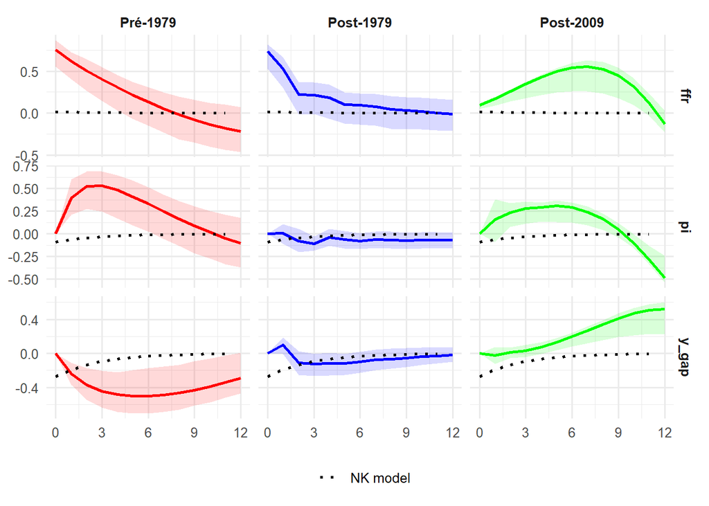

```r
var_pre <- VAR(Y_pre_ts,  p = p_pre,  type = "const")
var_post <- VAR(Y_post_ts, p = p_post, type = "const")
var_end <- VAR(Y_end_ts, p = p_post, type = "const")

irf_pre <- irf(
  var_pre,
  impulse = "ffr",
  response = c("y_gap", "pi", "ffr"),
  n.ahead = 12,
  boot = TRUE,
  runs = 500,
  ortho = TRUE  # Cholesky
)


irf_post <- irf(
  var_post,
  impulse = "ffr",
  response = c("y_gap", "pi", "ffr"),
  n.ahead = 12,
  boot = TRUE,
  runs = 500,
  ortho = TRUE
)

irf_end <- irf(
  var_end,
  impulse = "ffr",
  response = c("y_gap", "pi", "ffr"),
  n.ahead = 12,
  boot = TRUE,
  runs = 500,
  ortho = TRUE
)
df_irf_pre  <- irf_to_df(irf_pre, impulse_name = "ffr")
df_irf_post <- irf_to_df(irf_post, impulse_name = "ffr")
df_irf_end <- irf_to_df(irf_end, impulse_name = "ffr")

df_irf_pre$period  <- factor("Pré-1979", levels = c("Pré-1979", "Post-1979","Post-2009"))
df_irf_post$period <- factor("Post-1979", levels = c("Pré-1979", "Post-1979","Post-2009"))
df_irf_end$period <- factor("Post-2009", levels = c("Pré-1979", "Post-1979","Post-2009"))

nk_df_long <- nk_df %>%
  mutate(lower = irf, upper = irf) %>%
  expand_grid(period = c("Pré-1979", "Post-1979","Post-2009"))

df_irf_all <- bind_rows(df_irf_pre, df_irf_post,df_irf_end)


df_irf_all_plot <- df_irf_all %>%
  mutate(period_factor = factor(period, levels = c("Pré-1979", "Post-1979","Post-2009")))

nk_df_long_plot <- nk_df_long %>%
  mutate(period_factor = factor(period, levels = c("Pré-1979", "Post-1979","Post-2009")))

ggplot() +
  geom_ribbon(data = df_irf_all_plot,
              aes(x = horizon, ymin = lower, ymax = upper, fill = period_factor),
              alpha = 0.15, color = NA, show.legend = FALSE) +
  geom_line(data = df_irf_all_plot,
            aes(x = horizon, y = irf, color = period_factor),
            size = 1, show.legend = FALSE) +
  geom_line(data = nk_df_long_plot,
            aes(x = horizon, y = irf, linetype = "NK model"),
            color = "black", size = 1) +
  facet_grid(variable ~ period_factor, scales = "free_y") +
  scale_color_manual(values = c("Pré-1979" = "red", "Post-1979" = "blue","Post-2009" = "green")) +
  scale_fill_manual(values = c("Pré-1979" = "red", "Post-1979" = "blue", "Post-2009" = "green")) +
  scale_linetype_manual(name = "", values = c("NK model" = "dotted")) +
  labs(title = NULL, x = NULL, y = NULL) +
scale_x_continuous(breaks = seq(0, 12, by = 3)) +
  theme_minimal(base_size = 12) +
  theme(
    legend.position = "bottom",
  plot.title = element_text(face = "bold", hjust = 0.5,size = 12),
    strip.text = element_text(face = "bold")
  )
```

```r
ggsave("sorties/baseline.png", width = 7, height = 4, dpi = 300)
```

We want to illustrate where the price puzzle comes from before 1979 and after 2009. We plot the Forecast Error Variance Decomposition (FEVD) after the ffr shock.

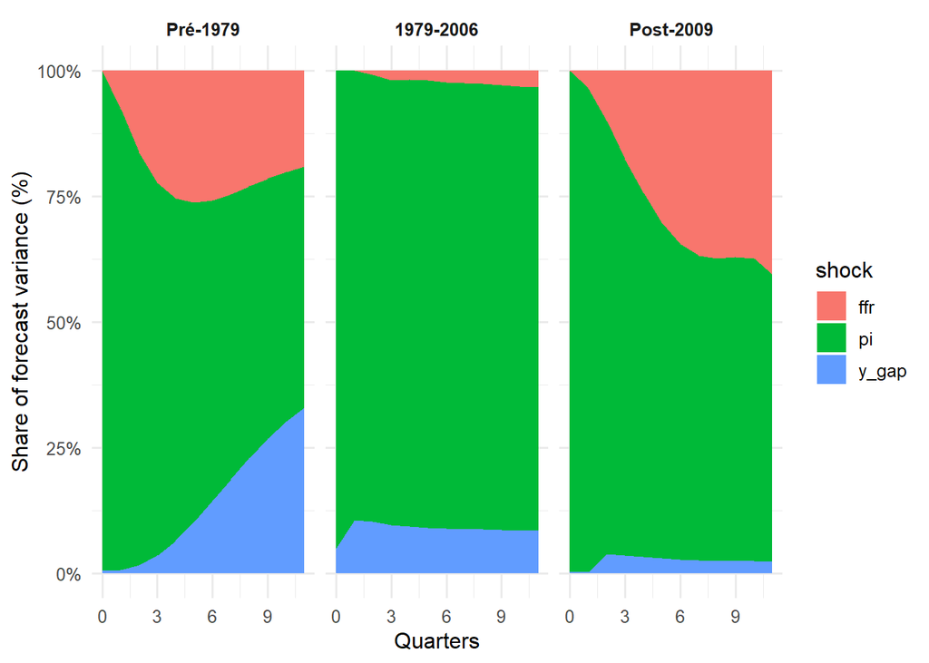

```r
fevd_pre  <- fevd(var_pre,  n.ahead = 12)
fevd_post <- fevd(var_post, n.ahead = 12)
fevd_end  <- fevd(var_end,  n.ahead = 12)

fevd_to_df <- function(fevd_obj, var_name, period_label) {
  mat <- fevd_obj[[var_name]]           # matrice horizons x variables
  df  <- as.data.frame(mat)
  df$horizon <- 0:(nrow(df) - 1)

  df %>%
    pivot_longer(
      cols = -horizon,
      names_to = "shock",
      values_to = "share"
    ) %>%
    mutate(period = period_label)
}

fevd_pi_all <- bind_rows(
  fevd_to_df(fevd_pre,  "pi", "Pré-1979"),
  fevd_to_df(fevd_post, "pi", "1979-2006"),
  fevd_to_df(fevd_end,  "pi", "Post-2009")
) %>%
  mutate(
    period = factor(period, levels = c("Pré-1979", "1979-2006", "Post-2009"))
  )

ggplot(fevd_pi_all, aes(x = horizon, y = share, fill = shock)) +
  geom_area(position = "stack") +
  facet_wrap(~ period, nrow = 1) +
  scale_y_continuous(labels = scales::percent_format(accuracy = 1)) +
  labs(
    title = NULL,
    x = "Quarters",
    y = "Share of forecast variance (%)"
  ) +
  theme_minimal(base_size = 12) +
  theme(
    strip.text = element_text(face = "bold"),
    plot.title = element_text(face = "bold", hjust = 0.5)
  )
```

```r
ggsave("sorties/fevd.png", width = 7, height = 4, dpi = 300)
```

Let’s see the estimated coefficients of the VAR.

```r
lapply(var_pre$varresult, function(eq) coef(eq))
```

```
$y_gap
  y_gap.l1      pi.l1     ffr.l1      const
 0.9993527  0.1640469 -0.3173465  1.0524698

$pi
   y_gap.l1       pi.l1      ffr.l1       const
-0.04246689  0.47596593  0.52646227 -0.48356329

$ffr
 y_gap.l1     pi.l1    ffr.l1     const
0.1851626 0.1151137 0.8152307 0.5151029
```

```r
lapply(var_post$varresult, function(eq) coef(eq))
```

```
$y_gap
   y_gap.l1       pi.l1      ffr.l1    y_gap.l2       pi.l2      ffr.l2
 1.09202429  0.01026345  0.13663942  0.03284261  0.17233679 -0.39770459
   y_gap.l3       pi.l3      ffr.l3       const
-0.22738382 -0.18583750  0.23289788  0.16439747

$pi
    y_gap.l1        pi.l1       ffr.l1     y_gap.l2        pi.l2       ffr.l2
 0.228699870  0.689683250  0.007192187 -0.299386336  0.090202782 -0.146833720
    y_gap.l3        pi.l3       ffr.l3        const
 0.127716230  0.187475696  0.104202428  0.256021093

$ffr
  y_gap.l1      pi.l1     ffr.l1   y_gap.l2      pi.l2     ffr.l2   y_gap.l3
 0.7307675  0.1249359  0.7169209 -0.2821247  0.5416494 -0.3172877 -0.2630269
     pi.l3     ffr.l3      const
-0.2896353  0.4606265 -0.2671760
```

Before 1979, the ffr coefficient is positive and large. Before Volcker, the Fed typically raised interest rates in response to expected increases in inflation (poor monetary policy rules, focus on output and unemployment, weak anti-inflation credibility). The VAR confuses cause and consequence. No Phillips curve effect : output gap has no effect on inflation. Apparent but spurious price puzzle.

# 4 Solving the price puzzle: pre-Volcker regime

Following Castelnuovo et al., we propose a sign restrictions approach. We impose that after a monetary shock, ffr > 0 and outputggap < 0. Inflation remains unconstrained.

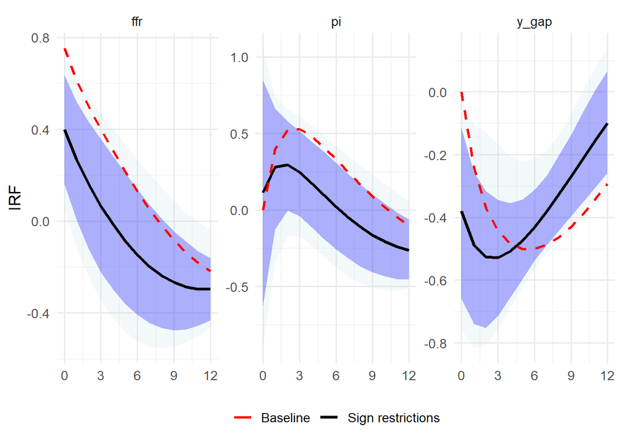

```r
chol_pre3 <- irf_pre$irf$ffr
vars_pre3 <- colnames(chol_pre3)

irf_pre3_df <- bind_rows(
  lapply(1:3, function(j)
    tibble(variable = vars_pre3[j], h = 0:12, irf = chol_pre3[1:13, j])
  )
) %>%
  mutate(model = "Baseline")

sr_res <- compute_sr_irf(
  var_fit      = var_pre,
  restrictions = sr_monetary,
  horizon      = 12,
  n.sim        = 5000,
  model_name   = "Sign restrictions"
)

irf_summary <- sr_res$irf_summary
irfs_kept <- sr_res$irfs_kept
B_kept    <- sr_res$B_kept
B_all <- sr_res$B_all

ggplot() +
  geom_ribbon(
    data = irf_summary,
    aes(x = horizon, ymin = lower90, ymax = upper90),
    fill = "lightblue", alpha = .15
  ) +
  geom_ribbon(
    data = irf_summary,
    aes(x = horizon, ymin = lower68, ymax = upper68),
    fill = "blue", alpha = .30
  ) +
  geom_line(
    data = irf_summary,
    aes(x = horizon, y = irf,
        color = "Sign restrictions",
        linetype = "Sign restrictions"),
    size = 1.2
  ) +
  geom_line(
    data = irf_pre3_df,
    aes(x = h, y = irf,
        color = "Baseline",
        linetype = "Baseline"),
    size = 1
  ) +
  facet_wrap(~variable, scales = "free_y") +
  scale_color_manual(values = c(
    "Baseline" = "red",
    "Sign restrictions" = "black"
  )) +
  scale_linetype_manual(values = c(
    "Baseline" = "dashed",
    "Sign restrictions" = "solid"
  )) +
  scale_x_continuous(breaks = seq(0,12,3)) +
  labs(x = NULL, y = "IRF") +
  theme_minimal(base_size = 13) +
  theme(
    legend.position = "bottom",
    legend.title = element_blank()
  ) +
  guides(linetype = "none")
```

```r
ggsave("sorties/sr.png", width = 7, height = 4, dpi = 300)
```

We observe the IRFs at t=0 in the plane (ffr(0), ogap(0))

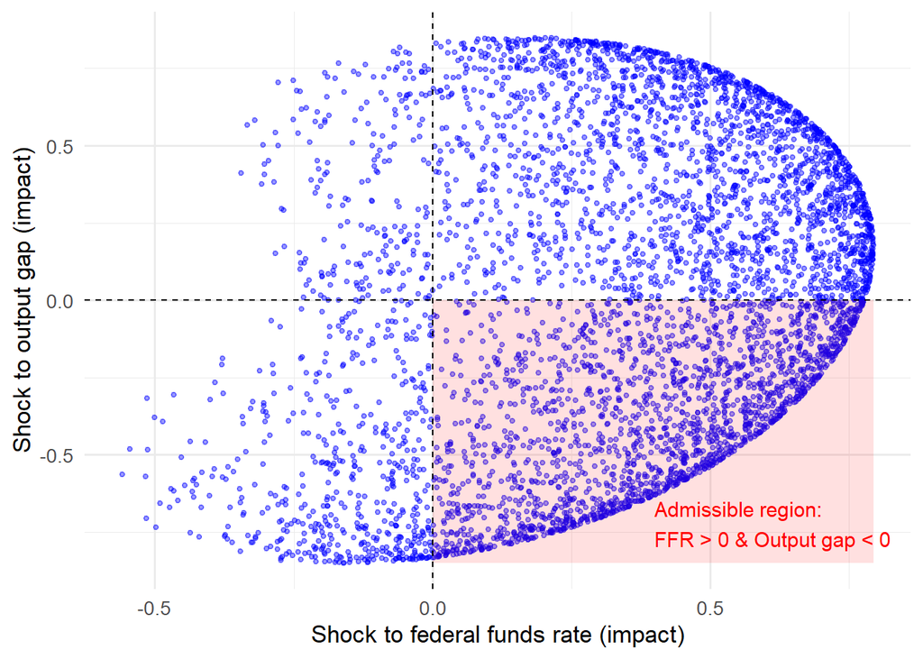

```r
df_shocks <- purrr::map_dfr(
  B_all,
  ~ tibble(
    ffr_shock  = .x["ffr",   "ffr"],
    ygap_shock = .x["y_gap", "ffr"],
    pi_shock   = .x["pi",    "ffr"]
  )
)

xmin <- 0
xmax <- max(df_shocks$ffr_shock,  na.rm = TRUE)
ymin <- min(df_shocks$ygap_shock, na.rm = TRUE)
ymax <- 0

ggplot(df_shocks, aes(x = ffr_shock, y = ygap_shock)) +
    geom_point(
    alpha = 0.4,
    color = "blue1",
    size = 1
  ) +
    annotate(
    "rect",
    xmin = xmin, xmax = xmax,
    ymin = ymin, ymax = ymax,
    fill = "red",
    alpha = 0.12
  ) +
    geom_vline(xintercept = 0, linetype = "dashed", linewidth = 0.5) +
  geom_hline(yintercept = 0, linetype = "dashed", linewidth = 0.5) +
  annotate(
    "text",
    x = 0.4,
    y = ymin * 0.85,
    label = "Admissible region:\nFFR > 0 & Output gap < 0",
    color = "red",
    size = 4,
    hjust = 0
  ) +

  labs(
    x = "Shock to federal funds rate (impact)",
    y = "Shock to output gap (impact)"
  ) +

  theme_minimal(base_size = 13)
```

```r
ggsave("sorties/rotation.png", width = 7, height = 4, dpi = 300)
```

We propose now to augment the VAR. As suggested by Casteluovo, we get the inflation forecasts from the Greenbook.

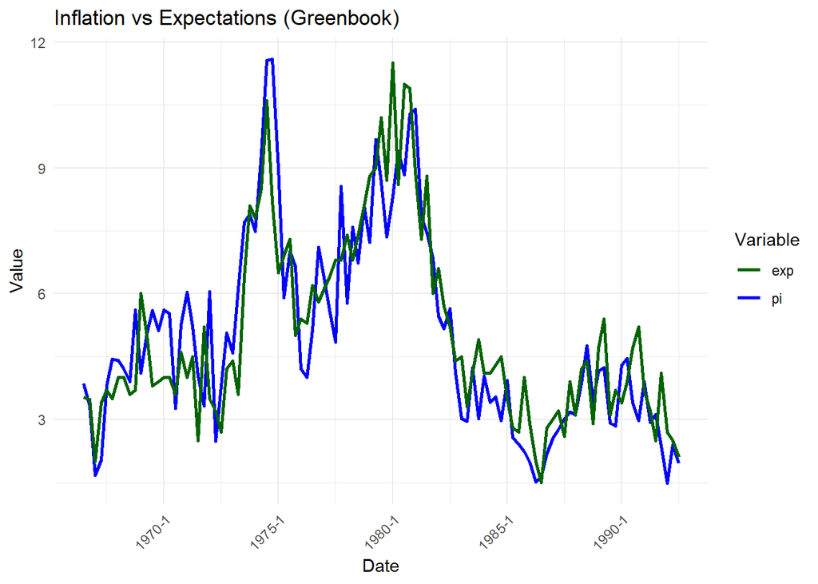

```r
green <- read.xlsx("data/greenbook.xlsx")

df <- df_us %>%
  mutate(date = gsub(" ", "", date)) %>%
  inner_join(green, by = "date")

df_inf <- df %>%
  dplyr::select(date, pi, green) %>%
  mutate(
    pi = as.numeric(pi),
    green = as.numeric(green),
    date = as.yearqtr(date, format = "%YQ%q")
  )

ggplot(df_inf, aes(x = date)) +
  theme_minimal() +
  geom_line(aes(y = pi, color = "pi"), linewidth = 1) +
  geom_line(aes(y = green, color = "exp"), linewidth = 1) +
  scale_color_manual(values = c("pi" = "blue", "exp" = "darkgreen")) +
  labs(
    x = "Date",
    y = "Value",
    color = "Variable",
    title = "Inflation vs Expectations (Greenbook)"
  ) +
  theme(axis.text.x = element_text(angle = 45, hjust = 1))
```

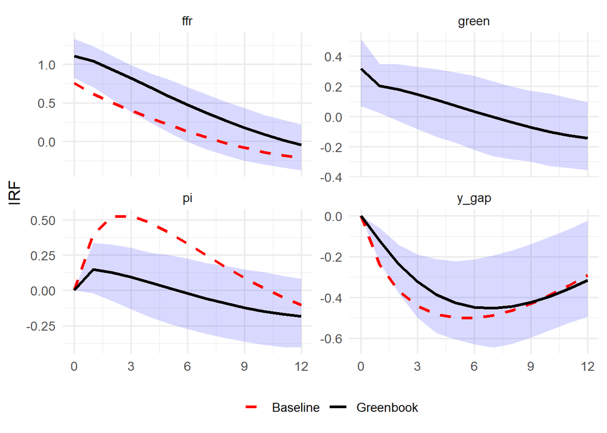

```r
df_ts <- df_to_ts(df)
lags_exp <- VARselect(df_ts, lag.max = 8, type = "const")$selection["SC(n)"]
VAR_exp <- VAR(df_ts, p = lags_exp, type = "const")

irf_exp <- irf(
  VAR_exp,
  impulse = "ffr",
  response = c("green", "y_gap", "pi", "ffr"),
  n.ahead = 12,
  boot = TRUE,
  runs = 500,
  ortho = TRUE
)

irf_exp_df <- irf_to_df(irf_exp, impulse_name = "ffr") %>%
  mutate(model = "Greenbook")

irf_pre_df <- irf_to_df(irf_pre, impulse_name = "ffr") %>%
  mutate(model = "Baseline")

green_missing <- irf_pre_df %>%
  filter(variable == "pi") %>%
  mutate(
    variable = "green",
    irf = NA, lower = NA, upper = NA
  )

irf_pre_df <- bind_rows(irf_pre_df, green_missing)

irf_green <- bind_rows(irf_exp_df, irf_pre_df) %>%
  mutate(model = factor(model, levels = c("Baseline", "Greenbook")))

ggplot() +
  geom_ribbon(
    data = irf_green %>% filter(model == "Greenbook"),
    aes(x = horizon, ymin = lower, ymax = upper, fill = model),
    alpha = 0.15, color = NA, fill = "blue"
  ) +
  geom_line(
    data = irf_green,
    aes(x = horizon, y = irf, color = model, linetype = model),
    size = 1.1
  ) +
  facet_wrap(~variable, scales = "free_y") +
  scale_color_manual(values = c("Baseline" = "red",
                                "Greenbook" = "black")) +
  scale_fill_manual(values = c("Greenbook" = "black")) +
  scale_linetype_manual(values = c("Baseline" = "dashed",
                                   "Greenbook" = "solid")) +
  labs(
    x = NULL,
    y = "IRF",
    title = NULL,
    color = NULL,
    linetype = NULL
  ) +
  theme_minimal(base_size = 13) +
  theme(legend.position = "bottom") +
  guides(fill = "none") +
scale_x_continuous(breaks = seq(0, 12, by = 3))
```

```r
ggsave("sorties/greenbook.png", width = 7, height = 4, dpi = 300)
```

The puzzle still exists but is less apparent. Let’s see the coefficients.

```r
lapply(VAR_exp$varresult, function(eq) coef(eq))
```

```
$y_gap
   y_gap.l1       pi.l1      ffr.l1    green.l1       const
 0.88344814 -0.06479383 -0.12814735  0.06907307  0.89994586

$pi
  y_gap.l1      pi.l1     ffr.l1   green.l1      const
 0.1155108  0.3869388 -0.0412038  0.6150082  0.2956949

$ffr
   y_gap.l1       pi.l1      ffr.l1    green.l1       const
 0.12795947 -0.06819249  0.87796099  0.21532011  0.23970362

$green
  y_gap.l1      pi.l1     ffr.l1   green.l1      const
0.05852386 0.31090651 0.02032802 0.57521931 0.44321311
```

```r
print(cov(resid(VAR_exp)))
```

```
            y_gap          pi       ffr      green
y_gap  0.67556221 -0.03715114 0.3657608 0.04844547
pi    -0.03715114  1.05263751 0.1288726 0.41435327
ffr    0.36576080  0.12887263 1.3958907 0.42357263
green  0.04844547  0.41435327 0.4235726 1.15097351
```

While the sensitivity of inflation to the federal funds rate becomes negative, a monetary policy shock still leads to an increase in inflation expectations in the short run. This pattern can be explained either by a **central bank information effect**, whereby policy tightening signals higher expected inflation to markets, or by **limited short-run credibility of the Federal Reserve** in anchoring inflation expectations.

Let’s compare inflation and inflation forecasts.

```r
df_leadlag <- df_inf %>%
  arrange(date) %>%
  mutate(
    Et_pi_t   = green,
    Etm1_pi_t = dplyr::lag(green, 1),
    Etm2_pi_t = dplyr::lag(green, 2)
  ) %>%
  drop_na()

c1 <- cor(df_leadlag$pi, df_leadlag$Et_pi_t)
c2 <- cor(df_leadlag$pi, df_leadlag$Etm1_pi_t)
c3 <- cor(df_leadlag$pi, df_leadlag$Etm2_pi_t)
cat(sprintf("Correlation between inflation and current expectations: %.3f\n", c1))
```

```
Correlation between inflation and current expectations: 0.865
```

```r
cat(sprintf("Correlation between inflation and 1-lagged expectations: %.3f\n", c2))
```

```
Correlation between inflation and 1-lagged expectations: 0.867
```

```r
cat(sprintf("Correlation between inflation and 2-lagged expectations: %.3f\n", c3))
```

```
Correlation between inflation and 2-lagged expectations: 0.770
```

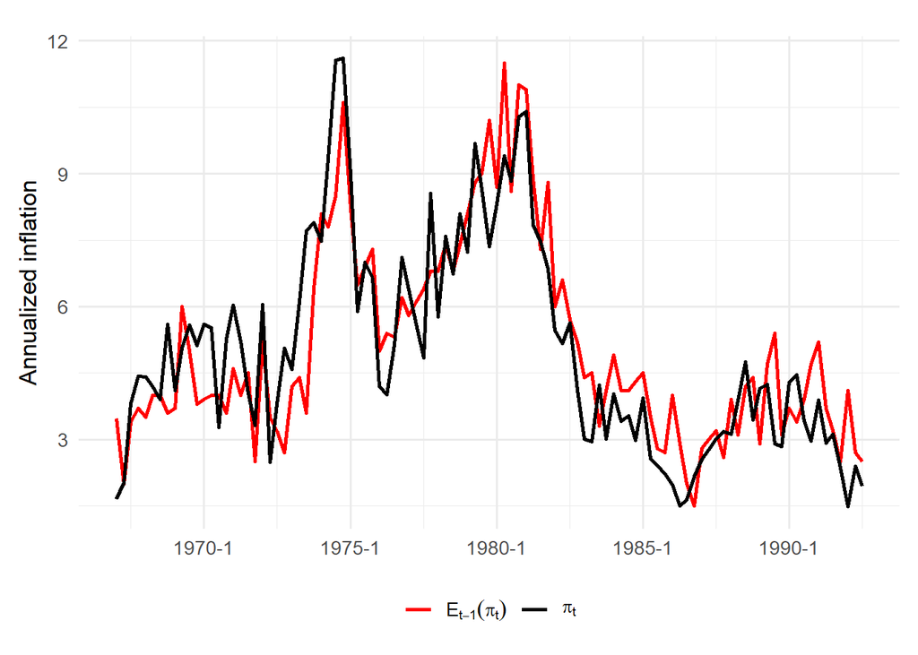

```r
df_plot <- df_leadlag %>%
  dplyr::select(date, pi, Etm1_pi_t) %>%
  pivot_longer(-date, names_to = "series", values_to = "value")

ggplot(df_plot, aes(x = date, y = value, color = series)) +
  geom_line(linewidth = 1) +
  scale_color_manual(
    values = c(
      pi = "black",
      Etm1_pi_t = "red"
    ),
    labels = c(
      pi = expression(pi[t]),
      Etm1_pi_t = expression(E[t-1](pi[t]))
    )
  ) +

  labs(
    x = NULL,
    y = "Annualized inflation",
    color = NULL,
    title = NULL
  ) +

  coord_cartesian(clip = "off") +

  theme_minimal(base_size = 13) +
  theme(
    legend.position = "bottom",
    plot.margin = margin(20, 10, 10, 10)
  )
```

```r
ggsave("sorties/greenbook_leadlag.png", width = 7, height = 4, dpi = 300)
```

Now let’s include sign restrictions in the VAR with 4 variables.

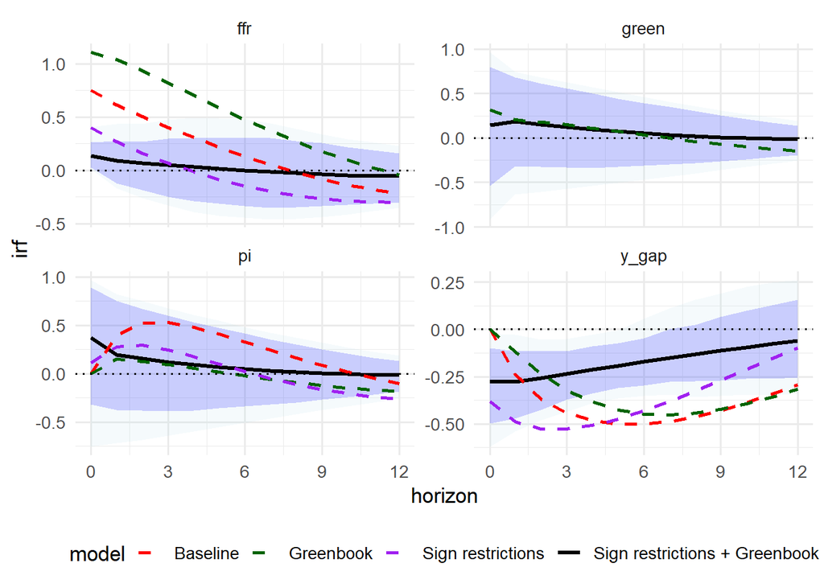

```r
baseline_df <- irf_pre_df %>%
  dplyr::select(variable, horizon, irf, model)

greenbook_df <- irf_exp_df %>%
  dplyr::select(variable, horizon, irf, model)

sr1 <- irf_summary %>%
  dplyr::select(variable,horizon,irf,model)

sr_gb_df <- compute_sr_irf(
  var_fit      = VAR_exp,
  restrictions = sr_monetary,
  horizon      = 12,
  n.sim        = 5000,
  model_name   = "Sign restrictions + Greenbook"
)

sr2 <- sr_gb_df$irf_summary

B_all2 <- sr_gb_df$B_all

irf_all <- bind_rows(
  baseline_df,
  greenbook_df,
  sr1
)

ggplot() +
  geom_ribbon(
    data = sr2,
    aes(x = horizon, ymin = lower90, ymax = upper90),
    fill = "lightblue", alpha = .12
  ) +
  geom_ribbon(
    data = sr2,
    aes(x = horizon, ymin = lower68, ymax = upper68),
    fill = "blue", alpha = .18
  ) +
  geom_line(
    data = sr2,
    aes(x = horizon, y = irf, color = model, linetype = model),
    linewidth = 1.2
  ) +
  geom_line(
    data = irf_all,
    aes(x = horizon, y = irf, color = model, linetype = model),
    linewidth = 1
  ) +

  facet_wrap(~variable, scales="free_y") +
  geom_hline(yintercept = 0, linetype="dotted") +
  scale_x_continuous(breaks = seq(0,12,3)) +

  scale_color_manual(values = c(
    "Baseline" = "red",
    "Greenbook" = "darkgreen",
    "Sign restrictions" = "purple",
    "Sign restrictions + Greenbook" = "black"
  )) +
  scale_linetype_manual(values = c(
    "Baseline" = "dashed",
    "Greenbook" = "dashed",
    "Sign restrictions" = "dashed",
    "Sign restrictions + Greenbook" = "solid"
  )) +

  theme_minimal(base_size = 13) +
  theme(legend.position = "bottom")
```

```r
ggsave("sorties/final.png", width=7, height=4, dpi=300)
```

This combination of sign restrictions and forecast variables does not outperform either identification strategy taken separately. In the VAR, this reflects the fact that once central bank information is explicitly controlled for, the identified monetary policy shock no longer corresponds to a purely exogenous policy disturbance. In particular, during the pre-1979 period, monetary policy appears to have been largely endogenous, reacting primarily to agents’ inflation expectations rather than exerting an independent stabilizing role.

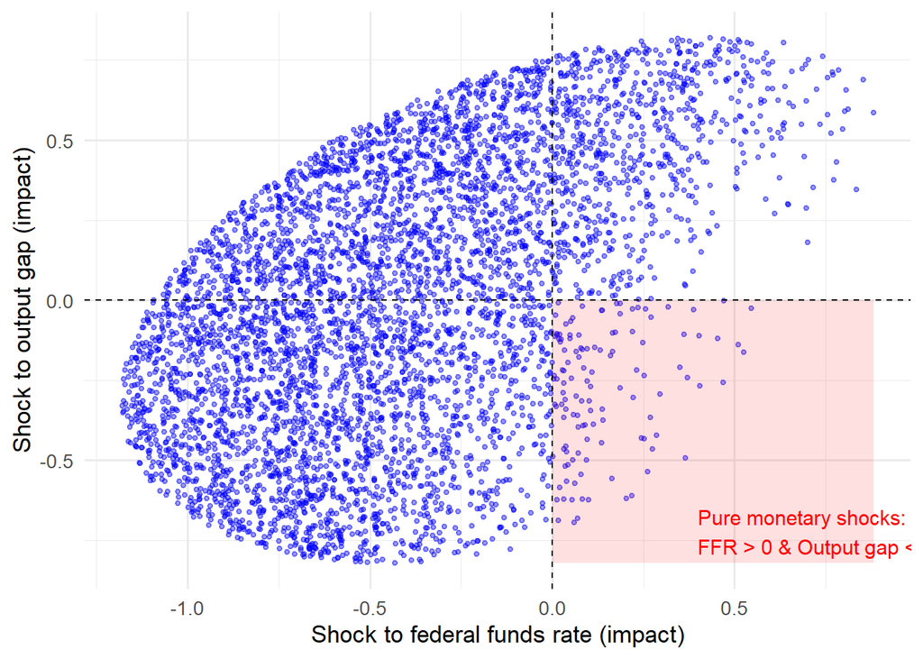

```r
df_shocks2 <- purrr::map_dfr(
  B_all2,
  ~ tibble(
    ffr_shock  = .x["ffr",   "ffr"],
    ygap_shock = .x["y_gap", "ffr"],
    pi_shock   = .x["pi",    "ffr"]
  )
)

xmin2 <- 0
xmax2 <- max(df_shocks2$ffr_shock,  na.rm = TRUE)
ymin2<- min(df_shocks2$ygap_shock, na.rm = TRUE)
ymax2 <- 0

ggplot(df_shocks2, aes(x = ffr_shock, y = ygap_shock)) +
    geom_point(
    alpha = 0.4,
    color = "blue1",
    size = 1
  ) +
    annotate(
    "rect",
    xmin = xmin2, xmax = xmax2,
    ymin = ymin2, ymax = ymax2,
    fill = "red",
    alpha = 0.12
  ) +
    geom_vline(xintercept = 0, linetype = "dashed", linewidth = 0.5) +
  geom_hline(yintercept = 0, linetype = "dashed", linewidth = 0.5) +
    annotate(
    "text",
    x = 0.4,
    y = ymin * 0.85,
    label = "Pure monetary shocks:\nFFR > 0 & Output gap < 0",
    color = "red",
    size = 4,
    hjust = 0
  ) +

  labs(
    x = "Shock to federal funds rate (impact)",
    y = "Shock to output gap (impact)"
  ) +
  theme_minimal(base_size = 13)
```

```r
ggsave("sorties/rotation2.png", width = 7, height = 4, dpi = 300)
```

# 5 Extensions to post-Volcker regimes

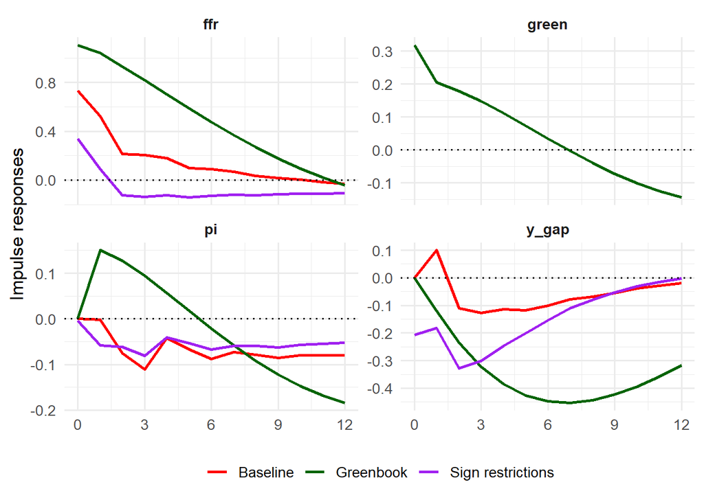

```r
df_post <- df_us %>%
  filter(date >= as.yearqtr("1979 Q4"),
         date <= as.yearqtr("2007 Q1"))

Y_post_ts <- df_post %>%
  dplyr::select(date, y_gap, pi, ffr) %>%
  df_to_ts()

p_post <- VARselect(Y_post_ts, lag.max = 8, type = "const")$selection["SC(n)"]
var_post <- VAR(Y_post_ts, p = p_post, type = "const")

irf_post <- irf(
  var_post,
  impulse  = "ffr",
  response = c("y_gap", "pi", "ffr"),
  n.ahead  = 12,
  boot     = TRUE,
  runs     = 500
)

irf_post_df <- irf_to_df(
  irf_post,
  impulse_name = "ffr"
) %>%
  mutate(model = "Baseline")



Y_post_gb_ts <- df_post %>%
  inner_join(greenbook,by="date") %>%
  dplyr::select(date, green=forecast_next_q, y_gap, pi, ffr) %>%
  df_to_ts()

p_gb <- VARselect(Y_post_gb_ts, lag.max = 8, type = "const")$selection["SC(n)"]
var_post_gb <- VAR(Y_post_gb_ts, p = p_gb, type = "const")

irf_gb <- irf(
  var_post_gb,
  impulse  = "ffr",
  response = c("green","y_gap","pi","ffr"),
  n.ahead  = 12,
  boot     = TRUE,
  runs     = 500
)


irf_exp_df <- irf_to_df(
  irf_exp,
  impulse_name = "ffr"
) %>%
  mutate(model = "Greenbook")



sr_post_df <- compute_sr_irf(
  var_fit    = var_post,
  restrictions = sr_monetary,
  horizon    = 12,
  n.sim      = 5000,
  model_name = "Sign restrictions"
)

sr_irf <- sr_post_df$irf_summary
irf_all_post <- bind_rows(
  irf_post_df,
  irf_exp_df,
  sr_irf
)

ggplot(irf_all_post,
       aes(x = horizon, y = irf,
           color = model, linetype = model)) +

  geom_line(linewidth = 1) +
  facet_wrap(~variable, scales = "free_y") +
  geom_hline(yintercept = 0, linetype = "dotted") +
  scale_x_continuous(breaks = seq(0, 12, 3)) +

  scale_color_manual(values = c(
    "Baseline" = "red",
    "Greenbook" = "darkgreen",
    "Sign restrictions" = "purple"
  )) +

  scale_linetype_manual(values = c(
    "Baseline" = "solid",
    "Greenbook" = "solid",
    "Sign restrictions" = "solid"
  )) +

  labs(
    x = NULL,
    y = "Impulse responses",
    color = NULL,
    linetype = NULL
  ) +

  theme_minimal(base_size = 13) +
  theme(
    legend.position = "bottom",
    strip.text = element_text(face = "bold")
  )
```

```r
ggsave("sorties/post79_baseline_green_sr.png",
       width = 7, height = 4, dpi = 300)
```

```r
lapply(var_post_gb$varresult, function(eq) coef(eq))
```

```
$green
     green.l1      y_gap.l1         pi.l1        ffr.l1         const
 0.0594742462 -0.0023385383  0.7006102514  0.1490875449 -0.0005357853

$y_gap
    green.l1     y_gap.l1        pi.l1       ffr.l1        const
-0.008815371  0.906834994 -0.019029259 -0.047273560  0.349674834

$pi
    green.l1     y_gap.l1        pi.l1       ffr.l1        const
 0.151491085  0.035510217  0.763822376 -0.009618447  0.265451117

$ffr
   green.l1    y_gap.l1       pi.l1      ffr.l1       const
-0.04831798  0.08984597  0.29312206  0.86123767  0.13333961
```

The price puzzle reappears in the 2010s, a period characterized by policy rates close to the zero lower bound, where rate increases primarily convey information rather than exert immediate contractionary effects.

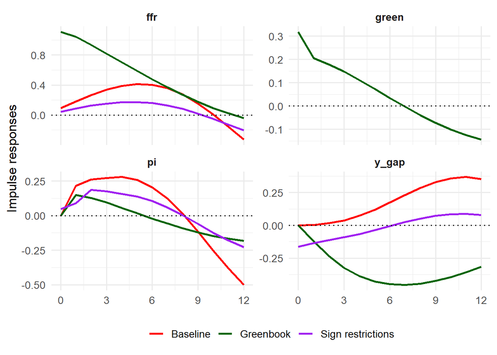

```r
df_end <- df_us %>%
  filter(date >= as.yearqtr("2009 Q4"),
         date <= as.yearqtr("2019 Q4"))

Y_end_ts <- df_end %>%
  dplyr::select(date, y_gap, pi, ffr) %>%
  df_to_ts()

p_end <- VARselect(Y_end_ts, lag.max = 8, type = "const")$selection["SC(n)"]
var_end<- VAR(Y_end_ts, p = p_end, type = "const")

irf_end <- irf(
  var_end,
  impulse  = "ffr",
  response = c("y_gap", "pi", "ffr"),
  n.ahead  = 12,
  boot     = TRUE,
  runs     = 500
)

irf_end_df <- irf_to_df(
  irf_end,
  impulse_name = "ffr"
) %>%
  mutate(model = "Baseline")



Y_end_gb_ts <- df_end %>%
  inner_join(greenbook,by="date") %>%
  dplyr::select(date, green=forecast_next_q, y_gap, pi, ffr) %>%
  df_to_ts()

p_gb <- VARselect(Y_end_gb_ts, lag.max = 8, type = "const")$selection["SC(n)"]
var_end_gb <- VAR(Y_end_gb_ts, p = 1, type = "const")

irf_end_gb <- irf(
  var_end_gb,
  impulse  = "ffr",
  response = c("green","y_gap","pi","ffr"),
  n.ahead  = 12,
  boot     = TRUE,
  runs     = 500
)


irf_exp_df <- irf_to_df(
  irf_exp,
  impulse_name = "ffr"
) %>%
  mutate(model = "Greenbook")



sr_end_df <- compute_sr_irf(
  var_fit    = var_end,
  restrictions = sr_monetary,
  horizon    = 12,
  n.sim      = 5000,
  model_name = "Sign restrictions"
)

sr_irf <- sr_end_df$irf_summary
irf_all_end <- bind_rows(
  irf_end_df,
  irf_exp_df,
  sr_irf
)

ggplot(irf_all_end,
       aes(x = horizon, y = irf,
           color = model, linetype = model)) +

  geom_line(linewidth = 1) +
  facet_wrap(~variable, scales = "free_y") +
  geom_hline(yintercept = 0, linetype = "dotted") +
  scale_x_continuous(breaks = seq(0, 12, 3)) +

  scale_color_manual(values = c(
    "Baseline" = "red",
    "Greenbook" = "darkgreen",
    "Sign restrictions" = "purple"
  )) +

  scale_linetype_manual(values = c(
    "Baseline" = "solid",
    "Greenbook" = "solid",
    "Sign restrictions" = "solid"
  )) +

  labs(
    x = NULL,
    y = "Impulse responses",
    color = NULL,
    linetype = NULL
  ) +

  theme_minimal(base_size = 13) +
  theme(
    legend.position = "bottom",
    strip.text = element_text(face = "bold")
  )
```

```r
ggsave("sorties/end79_baseline_green_sr.png",
       width = 7, height = 4, dpi = 300)
```

Let’s see the post-2008 coefficients. When the policy rate is close to zero, the VAR suggests that movements in the federal funds rate primarily reflect signaling normalization effects and increases expectations, leading to a price puzzle.

```r
lapply(var_end_gb$varresult, function(eq) coef(eq))
```

```
$green
   green.l1    y_gap.l1       pi.l1      ffr.l1       const
-0.16704691 -0.04546353  0.30700607  0.25915420  1.21160127

$y_gap
   green.l1    y_gap.l1       pi.l1      ffr.l1       const
 0.04646755  0.88246785 -0.09539605  0.21860211 -0.13001925

$pi
  green.l1   y_gap.l1      pi.l1     ffr.l1      const
-0.1063171 -0.1908187  0.1249538  0.3948820  1.0240089

$ffr
    green.l1     y_gap.l1        pi.l1       ffr.l1        const
-0.001440686  0.040512687  0.028342957  0.938298709  0.104423424
```